# Fitting logistic growth - state-space model (SSM)

Author

Benjamin Rosenbaum

## Model

The logistic growth model can be written in the $r,\alpha$ or the $r,K$ formulation, where $K=\frac{r}{\alpha}$, or $\alpha=\frac{r}{K}$:

$$\begin{aligned}
\frac{dN}{dt} &= (r-\alpha N)N \\ &=r(1-\frac{N}{K})N
\end{aligned}$$

Using a state-space model (including observation and process errors), we will fit all $m$ time series replicates with a joint set of parameters $r$ and $K$ (“complete pooling”). For each observation $N_{j,i}$ in $t_i$ of time series $j$, underlying true states `Ntrue[j,i]` are free parameters, which are estimated too.

## Data preparation

The dataset `data_example_logistic.csv` contains `m=6` timeseries with `n=18` observations of densities [ind] each, including their dates [h]. The fraction of the observed volume for sampling was `f=0.1`. Data preparation is identical to the OBS model manual.

```r
rm(list=ls())
library("rstan")
```

```r
data.in = read.csv("data_example_logistic.csv", row.names=1)

head(data.in)
```

```
     X1 X2  X3  X4  X5  X6  X7   X8   X9  X10  X11  X12  X13  X14  X15  X16
time  0 12  24  36  48  60  72   96  120  144  168  192  216  240  264  288
N1   10 36 106 270 562 914 994  968  904 1032 1010 1004  968 1010 1048  950
N2   24 30 136 262 532 846 942 1024 1024 1010 1016 1002 1082 1056  958 1088
N3   10 20 146 336 660 896 938  946 1016 1044  966  994 1004 1008 1086  932
N4   12 44 120 274 572 768 916 1010 1058 1066  992 1006  940  910 1016  998
N5   10 20  62 142 484 656 922  934 1000 1052  988 1004 1036 1056 1020  932
      X17  X18
time  312  336
N1    952 1072
N2   1078  954
N3   1006 1034
N4    916  972
N5   1062  976
```

```r
n = ncol(data.in)
m = nrow(data.in)-1

times = as.numeric(data.in[1, ])
N = unname(as.matrix(data.in[2:(m+1), ]))

data = list(n = n,
            m = m,
            t = times,
            N = N,
            f = 0.1)

str(data)
```

```
List of 5
 $ n: int 18
 $ m: num 6
 $ t: num [1:18] 0 12 24 36 48 60 72 96 120 144 ...
 $ N: int [1:6, 1:18] 10 24 10 12 10 10 36 30 20 44 ...
 $ f: num 0.1
```

## Stan model

The Stan model is coded as a string, which is compiled later. A step by step walkthrough is given below.

```r
stanmodelcode = "
functions{
  vector odemodel(real t, vector N, vector p){
    // p[1]=r, p[2]=K
    vector[1] dNdt;
    dNdt[1] = p[1]*(1-(N[1]/p[2]))*N[1];
    return dNdt;
  }
}

data{
  int n; // observations
  int m; // replicates
  array[n] real t;
  array[m,n] int N;
  real f;
}

parameters{
  real<lower=0> r;
  real<lower=0> K;
  real<lower=0> sigma;
  real<lower=0> tau;
  matrix<lower=0>[m,n] Ntrue; // states in times t
}

model{
  vector[2] p;
  array[1] vector[1] Nsim; // simulated values, matrix. dim1 = 1 point in time, dim2 = dim_ODE = 1

  // priors
  r ~ lognormal(-2,1);
  K ~ lognormal(9,1);
  sigma ~ lognormal(-2,1);
  tau ~ gamma(2,0.1);

  for(i in 1:m){
    Ntrue[i,1] ~ normal(0,100);
  }

  // parameters for integrator
  p[1] = r;
  p[2] = K;

  // process equations
  for(j in 1:m){
    for(i in 1:(n-1)){
      // integrate ODE
      Nsim = ode_rk45(odemodel, [Ntrue[j,i]]', t[i], {t[i+1]}, p);
      // process error
      Ntrue[j,i+1] ~ lognormal(log(Nsim[1,1]), sigma);
    }
  }

  // observation equations
  for(j in 1:m){
    for(i in 1:n){
      N[j,i] ~ neg_binomial_2(Ntrue[j,i]*f, tau);
    }
  }
}
"
```

### functions{ } block

This is identical to the OBS model manual.

```
  vector odemodel(real t, vector N, vector p){
    // p[1]=r, p[2]=K
    vector[1] dNdt;
    dNdt[1] = p[1]*(1-(N[1]/p[2]))*N[1];
    return dNdt;
  }
```

### data{ } block

This is identical to the OBS model manual.

```
  int n; // observations
  int m; // replicates
  array[n] real t;
  array[m,n] int N;
  real f;
```

### parameters{ } block

Here, all free parameters are declared. This includes model parameters `r` and `K`, and parameters `sigma` for the process residual distribution (scale parameter of lognormal) and `tau` for the observation residual distribution (overdispersion of the negative binomial). Additionally, for all `m` x `n` observations, the underlying true state `Ntrue` is estimated. All parameters are required to be positive.

```
  real<lower=0> r;
  real<lower=0> K;
  real<lower=0> sigma;
  real<lower=0> tau;
  matrix<lower=0>[m,n] Ntrue; // states in times t
```

### model{ } block

This block defines how the posterior computed, using prior distributions and the likelihood function. First, some intermediate variables for the ODE simulation are declared. `p` is a vector which stores model parameters `r` and `K`. `Nsim` will contain the output of the numerical integration with dimensions `1` (predict only next state), and the second dimension is number of states (here just 1).

```
  vector[2] p;
  array[1] vector[1] Nsim; // simulated values, matrix. dim1 = 1 point in time, dim2 = dim_ODE = 1
```

Priors: This is identical to the OBS and PROC model manual, initial densities parameters `Ntrue[i,1]` are assigned a weak prior, too.

[output not shown]

After the priors are defined, predictions are computed. This includes numerically integrating the ODE, which requires all model parameters are stored in one vector `p`.

```
  p[1] = r;
  p[2] = K;
```

The likelihood consists of two parts: the process equations and the observation equations.

In a first loop over all `m` time series replicates and `n-1` timepoints, numerical integration is performed, to predict the next true state `Ntrue[j,i+1]` from the current true state `Ntrue[j,i]`. The integration routine `ode_rk45()` is must be called in a specific format. Arguments are the function `odemodel` as defined in the `functions{}` block. The initial state is converted to a vector using `[ ]'`. Integration is performed from `t[i]` to `t[i+1]`. `p` contains the model parameters.

After computing the predicted state `Nsim` (in `t[i+1]`), it is confronted with estimate of `Ntrue[j,i+1]`: we assume a lognormal distribution, `sigma` denoting the process error.

```
  // process equations
  for(j in 1:m){
    for(i in 1:(n-1)){
      // integrate ODE
      Nsim = ode_rk45(odemodel, [Ntrue[j,i]]', t[i], {t[i+1]}, p);
      // process error
      Ntrue[j,i+1] ~ lognormal(log(Nsim[1,1]), sigma);
    }
  }
```

Second, the true states estimates `Ntrue[j,i]` are confronted with the data `N[j,i]`: a negative binomial distribution defines likelihood values. Since the data was sampled in a fraction `f=0.1`, the distribution’s mean is `Ntrue[,]*f`, with some overdispersion `tau`.

```
  // observation equations
  for(j in 1:m){
    for(i in 1:n){
      N[j,i] ~ neg_binomial_2(Ntrue[j,i]*f, tau);
    }
  }
```

## Model fitting

This is identical to the OBS model manual.

```r
# stan options
chains = 3
rstan_options(auto_write = TRUE)
options(mc.cores = chains)
iter   =  4000
warmup =  2000
```

Then starting values for all free parameters are provided as a list (in case of multiple chains: a list of lists). For the time series true states estimates `Ntrue`, observed data scaled up from the sampled fraction `f` to the total volume are a natural choice. Remaining parameters are given guesses. Stan usually converges quickly towards the parameter region featuring a high probability density. But with ODEs involved, good initial guesses that do not cause numerical issues in ODE integration are often required.

```r
# initial values for sampling
init=rep(list(list(r=0.1,
                   K=1e4,
                   sigma=0.1,
                   tau=10,
                   Ntrue=data$N/data$f
))
,chains)
```

Finally, the model is compiled and sampling is started.

```r
stanmodel = stan_model(model_code=stanmodelcode)

fit = sampling(stanmodel,
               data=data,
               iter=iter,
               warmup=warmup,
               chains=chains,
               init=init
)
```

## Model diagnostics

Convergence of the MCMC chains is checked, e.g. by looking at estimated model parameters. We check the effective sample size `n_eff` and the Gelman-Rubin diagnostics `Rhat` (should be <1.01), indicating that chains have mixed.

```r
print(fit, digits=3, pars=c("r","K","sigma","tau"), probs=c(0.025, 0.5, 0.975))
```

```
Inference for Stan model: anon_model.
3 chains, each with iter=4000; warmup=2000; thin=1;
post-warmup draws per chain=2000, total post-warmup draws=6000.

           mean se_mean     sd     2.5%       50%     97.5% n_eff  Rhat
r         0.098   0.000  0.002    0.094     0.098     0.102   964 1.001
K     10040.456   4.041 98.449 9839.786 10042.002 10236.129   594 1.011
sigma     0.017   0.001  0.008    0.006     0.016     0.035   117 1.027
tau     176.928   0.503 30.778  123.778   174.765   243.909  3739 1.000

Samples were drawn using NUTS(diag_e) at Thu Jan 25 17:10:04 2024.
For each parameter, n_eff is a crude measure of effective sample size,
and Rhat is the potential scale reduction factor on split chains (at
convergence, Rhat=1).
```

Additionally, chains are inspected visually via trace- and density plots.

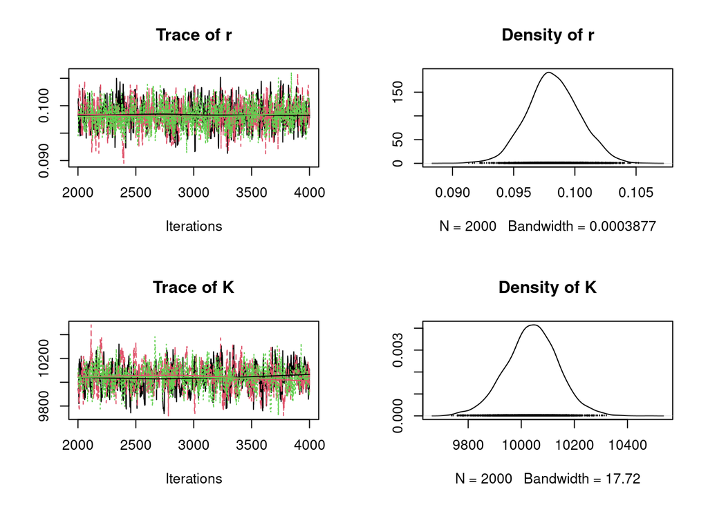

```r
library("coda")
samples=As.mcmc.list(fit)
plot(samples[, c("r","K")])
```

A pairs plot can detect correlations in model parameters. Almost perfect correlation would indicate non-identifiability.

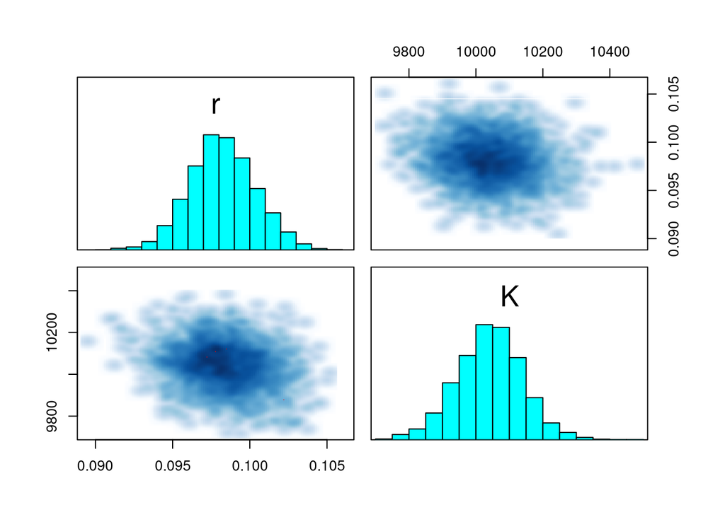

```r
pairs(fit, pars=c("r","K"))
```

## Posterior predictions

Since underlying true states `Ntrue[i,j]` for all observations `N[i,j]` are already estimated, we can directly pull their means, medians or CIs from the summary table. We plot them against the data (upscaled to total volume `data$N[,]/data$f`), for simplicity as piecewise linear interpolations between observations.

```r
summary = summary(fit)$summary

head(summary)
```

```
                   mean      se_mean           sd         2.5%          25%
r          9.823898e-02 6.871993e-05  0.002134025 9.417581e-02 9.685500e-02
K          1.004046e+04 4.040918e+00 98.449246272 9.839786e+03 9.977846e+03
sigma      1.721299e-02 7.128697e-04  0.007703668 5.660092e-03 1.135538e-02
tau        1.769282e+02 5.033241e-01 30.778325874 1.237780e+02 1.554346e+02
Ntrue[1,1] 1.124574e+02 2.950546e-01 10.807059762 9.264616e+01 1.049273e+02
Ntrue[1,2] 3.561389e+02 7.402491e-01 28.359935225 3.039226e+02 3.364670e+02
                    50%          75%        97.5%     n_eff     Rhat
r          9.817652e-02 9.964692e-02 1.024891e-01  964.3472 1.001485
K          1.004200e+04 1.010544e+04 1.023613e+04  593.5601 1.011049
sigma      1.598044e-02 2.190203e-02 3.452894e-02  116.7817 1.027108
tau        1.747649e+02 1.961693e+02 2.439085e+02 3739.3369 1.000027
Ntrue[1,1] 1.119563e+02 1.195561e+02 1.351970e+02 1341.5610 1.001145
Ntrue[1,2] 3.550365e+02 3.746809e+02 4.139980e+02 1467.7587 1.001103
```

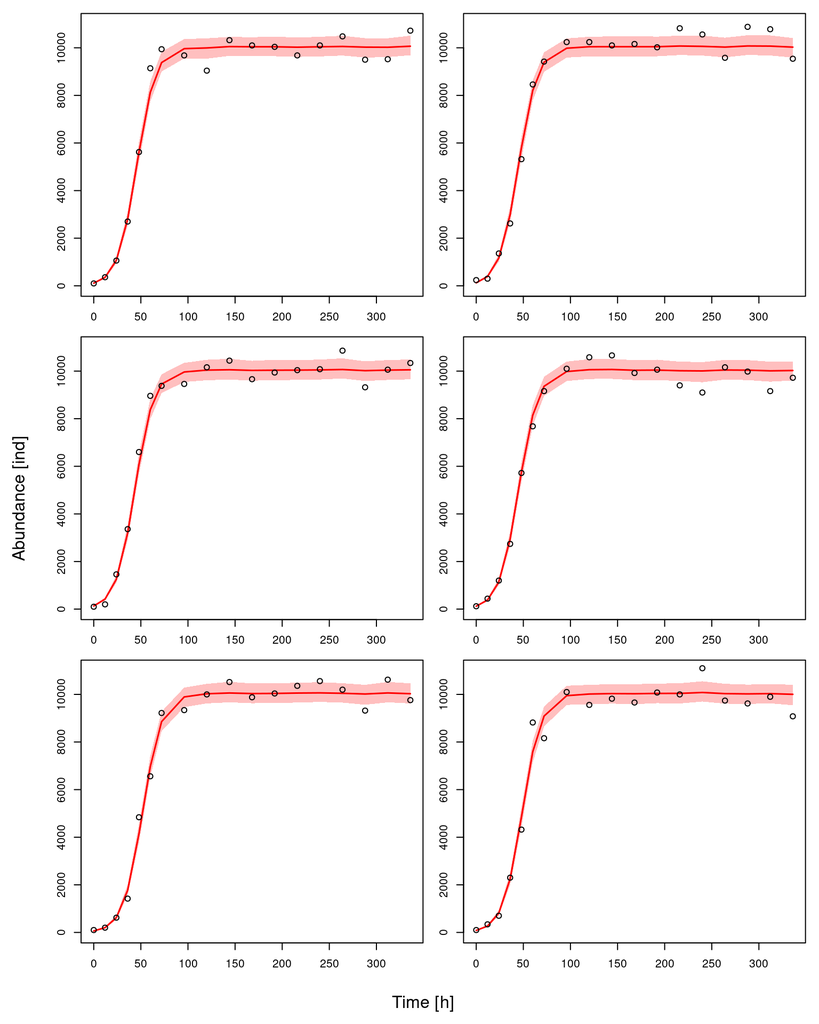

```r
N.pred.qs = matrix(NA, nrow=3, ncol=length(data$t))

par(mfrow=c(3,2), mar=c(3,3,0,0), oma=c(3,3,1,1))

for(i in 1:m){
  for(j in 1:length(times)){
    N.pred.qs[, j] = summary[paste0("Ntrue[",i,",",j,"]"), c("2.5%", "50%", "97.5%") ]
  }

  plot(data$t, data$N[i, ]/data$f, type="n", ylim=c(0,1.1e4), log="")
  polygon(c(data$t, rev(data$t)), c(N.pred.qs[1, ], rev(N.pred.qs[3, ])),
          col = adjustcolor("red",alpha.f=0.25),  border = NA)
  lines(data$t, N.pred.qs[2, ], col="red", lwd=1.5)
  points(data$t, data$N[i, ]/data$f)
}
mtext("Time [h]", side=1, outer=TRUE, line=1)
mtext("Abundance [ind]", side=2, outer=TRUE, line=1)
```